# Homework 04 - Statistical Methods for Data Science

Group A: Letícia Negrão Pinto, Federico Pigozzi, Niccolò Rossi

DSSC - 2019

# DAAG - Chapter 6

## Exercise 6

**The following investigates the consequences of not using a logarithmic transformation for the nihills data analysis. The second differs from the first in having a dist x climb interaction term, additional to linear terms in dist and climb.**

**(a) Fit the two models:**

**nihills.lm <- lm(time ~ dist+climb, data=nihills)**

**nihills2.lm <- lm(time ~ dist+climb+dist:climb, data=nihills)**

**anova(nihills.lm, nihills2.lm)**

Fitting the two models we can observe the following:

```r
library(DAAG)
# Model 1:
nihills.lm <- lm(time ~ dist + climb, data = nihills)
summary(nihills.lm)
```

```
##
## Call:
## lm(formula = time ~ dist + climb, data = nihills)
##
## Residuals:
##      Min       1Q   Median       3Q      Max
## -0.19857 -0.04824  0.01701  0.05539  0.21083
##
## Coefficients:
##               Estimate Std. Error t value Pr(>|t|)
## (Intercept) -2.286e-01  4.025e-02  -5.679 1.47e-05 ***
## dist         1.008e-01  1.382e-02   7.293 4.72e-07 ***
## climb        2.298e-04  2.893e-05   7.941 1.31e-07 ***
## ---
## Signif. codes:  0 '***' 0.001 '**' 0.01 '*' 0.05 '.' 0.1 ' ' 1
##
## Residual standard error: 0.0973 on 20 degrees of freedom
## Multiple R-squared:  0.9852, Adjusted R-squared:  0.9838
## F-statistic: 667.6 on 2 and 20 DF,  p-value: < 2.2e-16
```

```r
# Model 2:
nihills2.lm <- lm(time ~ dist + climb + dist:climb, data = nihills)
summary(nihills2.lm)
```

```
##
## Call:
## lm(formula = time ~ dist + climb + dist:climb, data = nihills)
##
## Residuals:
##      Min       1Q   Median       3Q      Max
## -0.07854 -0.03182 -0.01334  0.02894  0.08711
##
## Coefficients:
##              Estimate Std. Error t value Pr(>|t|)
## (Intercept) 4.677e-02  3.744e-02   1.249   0.2267
## dist        6.962e-02  7.427e-03   9.374 1.48e-08 ***
## climb       9.988e-05  2.040e-05   4.896   0.0001 ***
## dist:climb  9.964e-06  1.171e-06   8.509 6.62e-08 ***
## ---
## Signif. codes:  0 '***' 0.001 '**' 0.01 '*' 0.05 '.' 0.1 ' ' 1
##
## Residual standard error: 0.04552 on 19 degrees of freedom
## Multiple R-squared:  0.9969, Adjusted R-squared:  0.9964
## F-statistic:  2058 on 3 and 19 DF,  p-value: < 2.2e-16
```

```r
# Anova:
anova(nihills.lm, nihills2.lm)
```

```
## Analysis of Variance Table
##
## Model 1: time ~ dist + climb
## Model 2: time ~ dist + climb + dist:climb
##   Res.Df      RSS Df Sum of Sq      F    Pr(>F)
## 1     20 0.189361
## 2     19 0.039361  1      0.15 72.406 6.623e-08 ***
## ---
## Signif. codes:  0 '***' 0.001 '**' 0.01 '*' 0.05 '.' 0.1 ' ' 1
```

**(b) Using the F-test result, make a tentative choice of model**

The ‘anova()’ function computes analysis of variance (or deviance) tables for one or more fitted model objects. When given a sequence of objects, ‘anova()’ tests the models against one another in the order specified.

In this context, based purely on the output of the ‘anova()’ function, one tends to choose the *model number 2* as the one that better describes the data, since the p-value for the F-test is considered very low. However, it is not the final decision yet, since we still need to analyse the diagnostic plots.

**Proceed to examine diagnostic plots. Are there any problematic observations?**

In order to analyse the diagnostic plots, we can simply plot the fitted models. We may begin our analysis under the light of **Model number 1**:

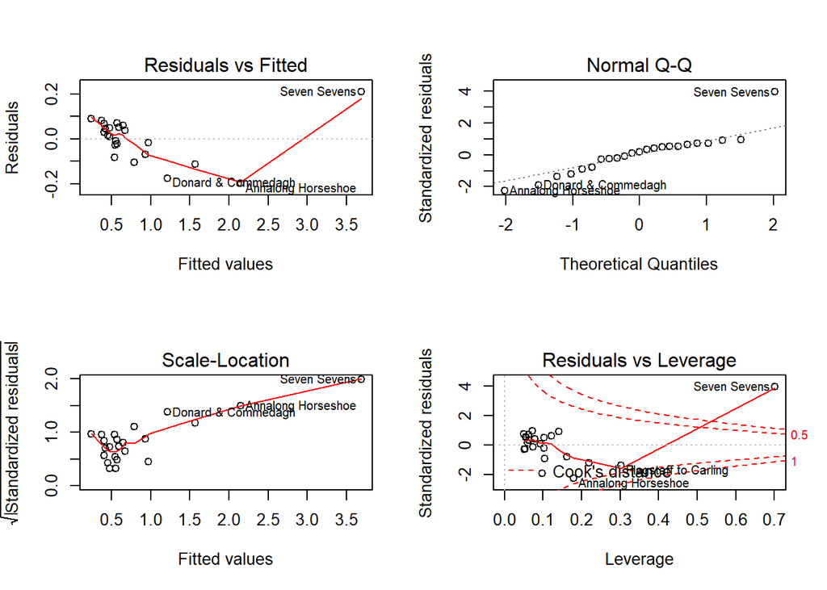

```r
par(mfrow = c(2,2))

# Model 1:
plot(nihills.lm)
```

The *first* graph, “*Residuals versus Fitted*”, shows if the residuals have non-linear patterns. It is possible to notice, from our plot, a “V” shaped curve, indicating that something is not well adjusted.

The *second* graph, “*Normal Q-Q*”, shows if residuals are normally distributed. It is possible to notice that most part of the residuals seem to follow the straight line well, but some of them, specially the “*Seven sevens*”, deviate.

The *third* graph, “*Scale-Location*”, shows if residuals are spread equally along the ranges of predictors. One can notice that in our graph most part of the residuals seem to be randomly spread, but the last three points seem to follow a straight line with a steep angle (*Seven sevens*, and *Annalong Horseshoe*).

Finally, the *fourth* graph, “*Residuals versus Leverage*”, helps us to find influential cases. One can notice the points related to *Seven sevens* and *Annalong Horseshoe* are highlighted in this context.

From the analysis of the Model number 1, it is possible to highlight the points Seven sevens and Annalong Horseshoe as problematic ones, in the sense that they are highly influential and may distort the entire analysis.

Now, considering **Model number 2**:

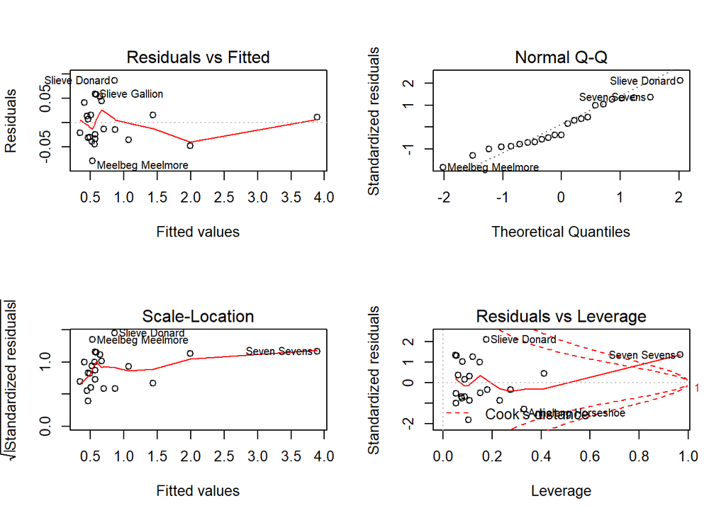

```r
par(mfrow = c(2,2))

# Model 2:
plot(nihills2.lm)
```

It is possible to notice that the point “*Seven Sevens*” still is identified as an influential one, even considering a different model.

**What happens if these points are removed? Refit both of the above models, and check the diagnostics again.**

Considering the same two models without the problematic observations, we have the following:

```r
# Excluding Outliers from the analysis:
exclude_outliers <- !row.names(nihills) %in% c("Seven Sevens",
                                            "Annalong Horseshoe")

# Model 1 - Without Outliers:
nihills.lm_out <- lm(time ~ dist + climb,
                        data = nihills[exclude_outliers,])
summary(nihills.lm_out)
```

```
##
## Call:
## lm(formula = time ~ dist + climb, data = nihills[exclude_outliers,
##     ])
##
## Residuals:
##      Min       1Q   Median       3Q      Max
## -0.08044 -0.03874  0.01284  0.03026  0.06847
##
## Coefficients:
##               Estimate Std. Error t value Pr(>|t|)
## (Intercept) -7.954e-02  2.982e-02  -2.667   0.0157 *
## dist         9.392e-02  6.555e-03  14.328 2.77e-11 ***
## climb        1.587e-04  1.719e-05   9.231 3.02e-08 ***
## ---
## Signif. codes:  0 '***' 0.001 '**' 0.01 '*' 0.05 '.' 0.1 ' ' 1
##
## Residual standard error: 0.04509 on 18 degrees of freedom
## Multiple R-squared:  0.973,  Adjusted R-squared:  0.9699
## F-statistic: 323.7 on 2 and 18 DF,  p-value: 7.748e-15
```

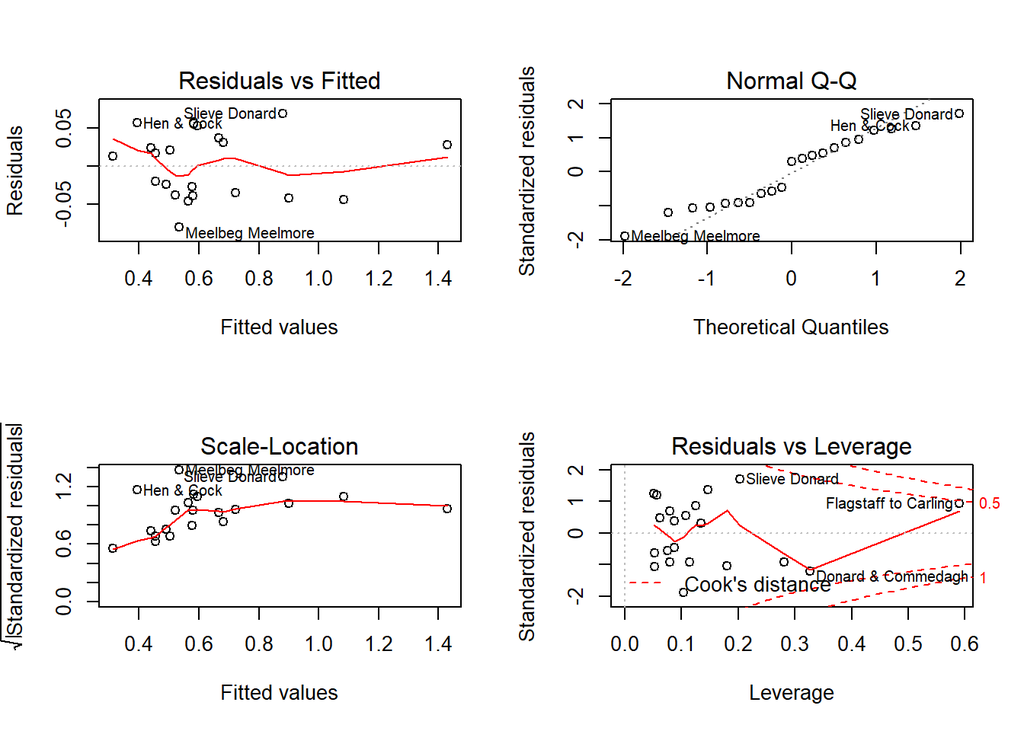

```r
# Diagnostic Plots - model 1 without outliers:
par(mfrow = c(2,2))
plot(nihills.lm_out)
```

```r
# Model 2 - Without Outliers:
nihills2.lm_out <- lm(time ~
                        dist + climb + dist:climb,
                        data = nihills[exclude_outliers,])
summary(nihills2.lm_out)
```

```
##
## Call:
## lm(formula = time ~ dist + climb + dist:climb, data = nihills[exclude_outliers,
##     ])
##
## Residuals:
##       Min        1Q    Median        3Q       Max
## -0.079989 -0.029783 -0.002539  0.038091  0.073430
##
## Coefficients:
##               Estimate Std. Error t value Pr(>|t|)
## (Intercept) -1.594e-02  9.325e-02  -0.171 0.866319
## dist         8.076e-02  1.942e-02   4.158 0.000659 ***
## climb        1.288e-04  4.496e-05   2.865 0.010725 *
## dist:climb   5.683e-06  7.881e-06   0.721 0.480697
## ---
## Signif. codes:  0 '***' 0.001 '**' 0.01 '*' 0.05 '.' 0.1 ' ' 1
##
## Residual standard error: 0.0457 on 17 degrees of freedom
## Multiple R-squared:  0.9738, Adjusted R-squared:  0.9691
## F-statistic: 210.2 on 3 and 17 DF,  p-value: 1.237e-13
```

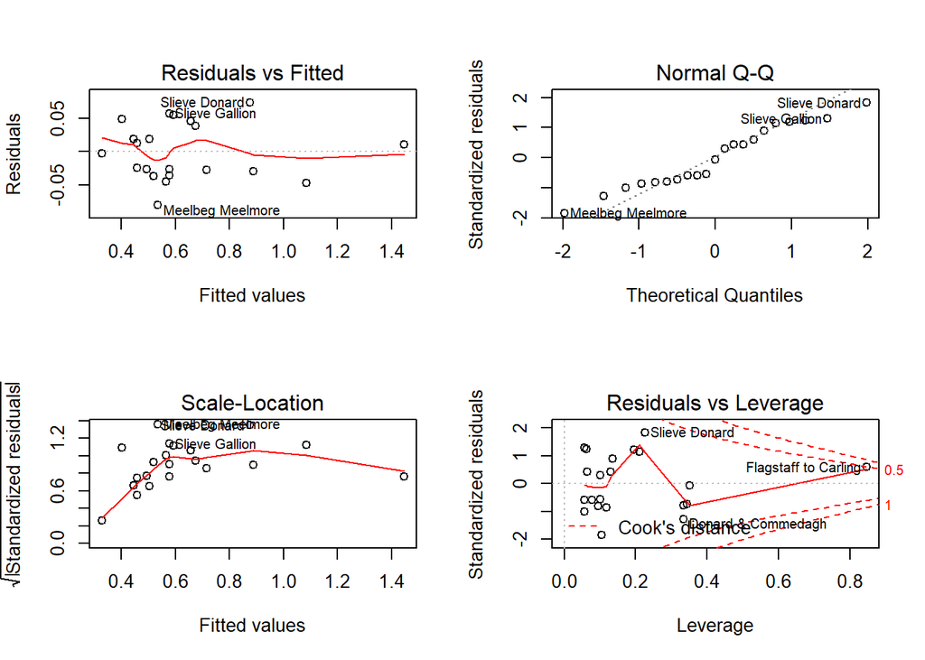

```r
# Diagnostic Plots - model 2 without outliers:
par(mfrow = c(2,2))
plot(nihills2.lm_out)
```

```r
# Anova:
anova(nihills.lm_out, nihills2.lm_out)
```

```
## Analysis of Variance Table
##
## Model 1: time ~ dist + climb
## Model 2: time ~ dist + climb + dist:climb
##   Res.Df      RSS Df Sum of Sq      F Pr(>F)
## 1     18 0.036592
## 2     17 0.035506  1 0.0010858 0.5199 0.4807
```

One can notice that the diagnostic plots now seems completely different. Now, excluding the outliers, the results of the ‘anova()’ functions suggest that *model number 1* is in fact better to describe the data. We can also reach this conclusion when analyzing separately the results for each model:

```r
# Anova:

# Model 1
anova(nihills.lm_out)
```

```
## Analysis of Variance Table
##
## Response: time
##           Df  Sum Sq Mean Sq F value    Pr(>F)
## dist       1 1.14306 1.14306 562.280 5.002e-15 ***
## climb      1 0.17322 0.17322  85.206 3.017e-08 ***
## Residuals 18 0.03659 0.00203
## ---
## Signif. codes:  0 '***' 0.001 '**' 0.01 '*' 0.05 '.' 0.1 ' ' 1
```

```r
# Model 2
anova(nihills2.lm_out)
```

```
## Analysis of Variance Table
##
## Response: time
##            Df  Sum Sq Mean Sq  F value    Pr(>F)
## dist        1 1.14306 1.14306 547.2821 2.277e-14 ***
## climb       1 0.17322 0.17322  82.9333 5.991e-08 ***
## dist:climb  1 0.00109 0.00109   0.5199    0.4807
## Residuals  17 0.03551 0.00209
## ---
## Signif. codes:  0 '***' 0.001 '**' 0.01 '*' 0.05 '.' 0.1 ' ' 1
```

Here we see that, when excluding the outliers, the variable “dist:climb”, used in model 2 does not help to describe the data, being *model number 1* preferable.

Using the AIC criterion we can reiterate our conclusion:

```r
# Comparing the models according to the AIC criterion

# AIC Model 1 - unchanged:
extractAIC(nihills.lm)[2]
```

```
## [1] -104.3907
```

```r
# AIC Model 2 - unchanged:
extractAIC(nihills2.lm)[2]
```

```
## [1] -138.5208
```

```r
# AIC Model 1 - without outliers:
extractAIC(nihills.lm_out)[2]
```

```
## [1] -127.4013
```

```r
# AIC Model 2 - without outliers:
extractAIC(nihills2.lm_out)[2]
```

```
## [1] -126.0339
```

Before excluding the outliers, model number 2 is preferred, with lower AIC. After the exclusion of the outliers, model number 1 is preferred, showing lower AIC.

## Exercise 7

**Check the variance inflation factors for bodywt and lsize for the model brainwt $\sim$ bodywt + lsize, fitted to the litters data set. Comment.**

```r
library(DAAG)
data <- litters
head(data)
```

```
##   lsize bodywt brainwt
## 1     3  9.447   0.444
## 2     3  9.780   0.436
## 3     4  9.155   0.417
## 4     4  9.613   0.429
## 5     5  8.850   0.425
## 6     5  9.610   0.434
```

First of all let’s produce a scatter plot of the two covariates.

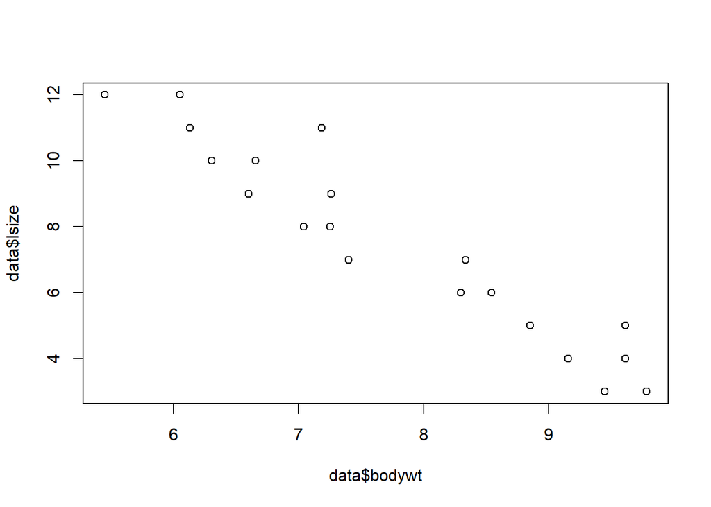

```r
plot(data$bodywt, data$lsize)
```

There seems to be some kind of linear relationship between the two variables. Now we’re going to build the linear model, and then we’re going to compute the VIF.

```r
model <- lm(brainwt ~ bodywt + lsize, data=data)
vif(model)
```

```
## bodywt  lsize
##  11.33  11.33
```

The result is the same for both bodywt and lsize since these are the only two covariates in the model, and the obtained value is above 10. The VIF confirms the presence of collinearity, which is not good for the estimates of the model parameters.

```r
summary(model)
```

```
##
## Call:
## lm(formula = brainwt ~ bodywt + lsize, data = data)
##
## Residuals:
##        Min         1Q     Median         3Q        Max
## -0.0230005 -0.0098821  0.0004512  0.0092036  0.0180760
##
## Coefficients:
##             Estimate Std. Error t value Pr(>|t|)
## (Intercept) 0.178247   0.075323   2.366  0.03010 *
## bodywt      0.024306   0.006779   3.586  0.00228 **
## lsize       0.006690   0.003132   2.136  0.04751 *
## ---
## Signif. codes:  0 '***' 0.001 '**' 0.01 '*' 0.05 '.' 0.1 ' ' 1
##
## Residual standard error: 0.01195 on 17 degrees of freedom
## Multiple R-squared:  0.6505, Adjusted R-squared:  0.6094
## F-statistic: 15.82 on 2 and 17 DF,  p-value: 0.0001315
```

In fact, the standard errors for the estimated parameters are quite high with respect to the estimates, which reflects in p-values for intercept and lsize that are not very distant from 0.05.

## Exercise 8

**Apply the lm.ridge() function to the litters data, using the generalized cross-validation (GCV) criterion to choose the tuning parameter. (GCV is an approximation to cross-validation.)**

**(a) In particular, estimate the coefficients of the model relating brainwt to bodywt and lsize and compare with the results obtained using lm().**

The function ‘lm.ridge()’ is used to fit a linear model by Ridge regression. That said, one can compute:

```r
library(MASS)
# Ridge regression with lambda = 0:
litters.ridge_l0 <- lm.ridge( brainwt ~ bodywt + lsize,
                           data = litters, lambda =0 )
litters.ridge_l0
```

```
##                  bodywt       lsize
## 0.178246962 0.024306344 0.006690331
```

```r
# Selecting lambda in terms of GCV error:
select(lm.ridge(brainwt ~ bodywt + lsize,
                           data = litters, lambda = seq(0,0.1,0.001)))
```

```
## modified HKB estimator is 0
## modified L-W estimator is 0
## smallest value of GCV  at 0.1
```

As can be seen, using the generalized cross-validation (GCV) criterion it was possible to choose the tuning parameter, ‘0.1’. Now using $\lambda=0.1$ we have the final Ridge regression:

```r
# Ridge regression with lambda given by GCV (0.1):
litters.ridge <- lm.ridge( brainwt ~ bodywt + lsize,
                           data = litters, lambda = 0.1 )
litters.ridge
```

```
##                bodywt      lsize
## 0.19998145 0.02236033 0.00580276
```

Now comparing with the ordinary linear regression:

```r
# Using ordinary linear regression:
litters.lm <- lm( brainwt ~ bodywt + lsize,
                           data = litters )
summary(litters.lm)
```

```
##
## Call:
## lm(formula = brainwt ~ bodywt + lsize, data = litters)
##
## Residuals:
##        Min         1Q     Median         3Q        Max
## -0.0230005 -0.0098821  0.0004512  0.0092036  0.0180760
##
## Coefficients:
##             Estimate Std. Error t value Pr(>|t|)
## (Intercept) 0.178247   0.075323   2.366  0.03010 *
## bodywt      0.024306   0.006779   3.586  0.00228 **
## lsize       0.006690   0.003132   2.136  0.04751 *
## ---
## Signif. codes:  0 '***' 0.001 '**' 0.01 '*' 0.05 '.' 0.1 ' ' 1
##
## Residual standard error: 0.01195 on 17 degrees of freedom
## Multiple R-squared:  0.6505, Adjusted R-squared:  0.6094
## F-statistic: 15.82 on 2 and 17 DF,  p-value: 0.0001315
```

As one can notice, the results given by ordinary linear regression are the same as Ridge regression with $\lambda=0$. Furthermore, comparing the coefficients given by the two regressions (Ridge with $\lambda \neq 0$) it is possible to notice that Ridge coefficients are a bit smaller, as expected.

**(b) Using both ridge and ordinary regression, estimate the mean brain weight when litter size is 10 and body weight is 7. Use the bootstrap, with case-resampling, to compute approximate 95% percentile confidence intervals using each method. Compare with the interval obtained using predict.lm().**

We can use the library ‘boot’ to asses the Bootstrap functions in R.

```r
# In order to estimate the mean brain weight when litter size is 10 and body weight is 7:
library(boot)
set.seed(2019)

# Estimating the Mean - ordinary linear regression:
mean_litters.lm <- unname(litters.lm$coefficients[1] +
                            7*litters.lm$coefficients[2] +
                           10*litters.lm$coefficients[3])

# Boot function - Ordinary linear regression:
mean_lm <- function(data, indices) {
  d <- data[indices,] # allows boot to select sample
  fit <- lm(d$brainwt ~ d$bodywt + d$lsize, data = d)
  return(fit$coefficients[1]+7*fit$coefficients[2]+10*fit$coefficients[3])
}

#Bootstrapping with 10^4 replications:
results_lm <- boot(data = litters, statistic= mean_lm,
                   R = 10^4, stype = "i")

# 95% confidence interval:
boot_ci_lm <- boot.ci(results_lm, conf = 0.95, type="all")
#boot_ci_lm

# Estimating the Mean - Ridge regression:
mean_litters.ridge <- coef(litters.ridge)[1] +
                    7*coef(litters.ridge)[2] +
                   10*coef(litters.ridge)[3]

# Boot function - Ridge regression:
mean_ridge <- function(data, indices) {
  d <- data[indices,] # allows boot to select sample
  fit <- lm.ridge(d$brainwt ~ d$bodywt + d$lsize, data=d, lambda = 0.1)
  return(coef(fit)[1]+7*coef(fit)[2]+10*coef(fit)[3])
}

#Bootstrapping with 10^4 replications - RIDGE:
results_ridge <- boot(data = litters, statistic = mean_ridge,
                      R = 10^4, stype = "i")

# 95% confidence interval - RIDGE:
boot_ci_ridge <- boot.ci(results_ridge, conf = 0.95, type="all")

# Comparing:
# Ordinary Linear Regression
mean_litters.lm
```

```
## [1] 0.4152947
```

```r
boot_ci_lm
```

```
## BOOTSTRAP CONFIDENCE INTERVAL CALCULATIONS
## Based on 10000 bootstrap replicates
##
## CALL :
## boot.ci(boot.out = results_lm, conf = 0.95, type = "all")
##
## Intervals :
## Level      Normal              Basic
## 95%   ( 0.4066,  0.4240 )   ( 0.4073,  0.4250 )
##
## Level     Percentile            BCa
## 95%   ( 0.4056,  0.4233 )   ( 0.4047,  0.4226 )
## Calculations and Intervals on Original Scale
```

```r
# Ridge Regression
mean_litters.ridge
```

```
##
## 0.4145314
```

```r
boot_ci_ridge
```

```
## BOOTSTRAP CONFIDENCE INTERVAL CALCULATIONS
## Based on 10000 bootstrap replicates
##
## CALL :
## boot.ci(boot.out = results_ridge, conf = 0.95, type = "all")
##
## Intervals :
## Level      Normal              Basic
## 95%   ( 0.4060,  0.4232 )   ( 0.4070,  0.4243 )
##
## Level     Percentile            BCa
## 95%   ( 0.4048,  0.4221 )   ( 0.4041,  0.4217 )
## Calculations and Intervals on Original Scale
```

It is possible to notice that the results given by the ordinary linear regression and Ridge regression are very close from each other, the estimate of the mean given by Ridge Regression being slightly smaller in this specific case. Comparing those results with the interval obtained using ‘predict.lm()’ we have the following:

```r
# Setting the values of the variables:
newdata <- data.frame( lsize = 10, bodywt = 7 )

# Prediction and interval given the new data:
predict.lm(litters.lm, newdata, interval = "predict", level=0.95)
```

```
##         fit       lwr       upr
## 1 0.4152947 0.3885067 0.4420826
```

One can notice that the interval given by the ‘predict.lm()’ function is wider than those given by the Bootstrap method (for $10^{4}$ replications).

## Exercise 10

**The data frame table.b3 in the MPV package contains data on gas mileage and 11 other variables for a sample of 32 automobiles.**

**(a) Construct a scatterplot of y (mpg) versus x1 (displacement). Is the relationship between these variables non-linear?**

```r
library(MPV)
library(lattice)

attach(table.b3) # in this way we directly have access to the variables
```

We constructed a scatter plot of y (mpg) against x1 (displacement).

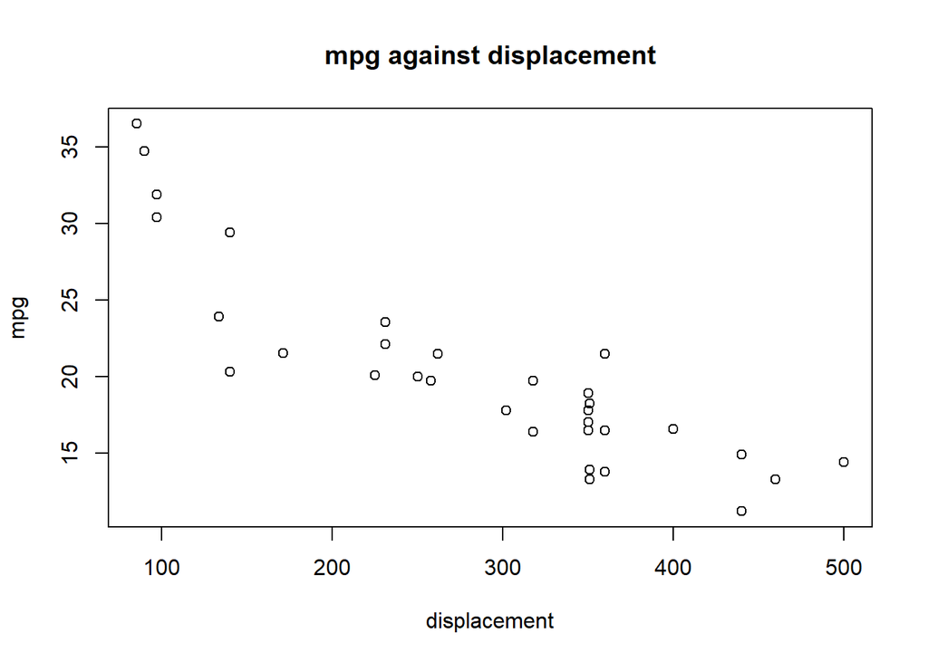

```r
plot(y ~ x1, xlab="displacement", ylab="mpg", main="mpg against displacement")
```

As we can see, the relationship between the two variables seems to be vaguely negatively linear. Nevertheless, a quadratic relationship could be more appropriate, as shown by the curvature of the ideal best fitting line as we approach the y axis, an evidence of non-linearity.

**(b) Use the xyplot() function, and x11 (type of transmission) as a group variable. Is a linear model reasonable for these data?**

We will now use the xyplot() function of the ‘lattice’ package. This function produces bivariate scatterplots or time-series plots. We call it on a formula describing the response variable and x1, and define x11 (type of transmission, binary categoric with 1=automatic and 0=manual) as conditioning variable.

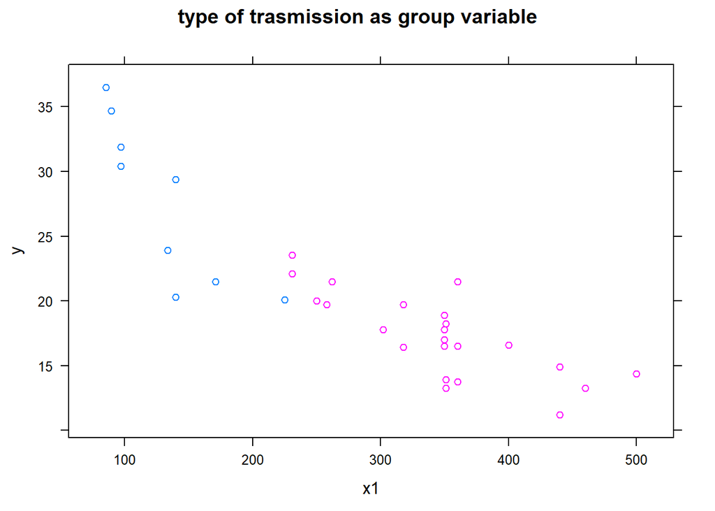

```r
xyplot(y ~ x1, group=x11, main="type of trasmission as group variable")
```

As we can see, arguing that the relationship is linear could be very inappropriate. In fact, it looks like there are two separate clusters in the data, one towards the left and one towards the right of the x axis, and each of them might be linear on its own.

**(c) Fit the model relating y to x1 and x11 which gives two lines having possibly different slopes and intercepts. Check the diagnostics. Are there any influential observations? Are there any influential outliers?**

We fit a model relating y to x1 and x11, using the ’*’ syntax which stands for x1, x11 and their interaction:

```r
par(mfrow=c(1,1))
model1 <- lm(y ~ x1*x11, data=table.b3)
summary(model1) # print useful information relative to the fitted model
```

```
##
## Call:
## lm(formula = y ~ x1 * x11, data = table.b3)
##
## Residuals:
##     Min      1Q  Median      3Q     Max
## -6.2712 -1.2660  0.1342  1.5181  4.6599
##
## Coefficients:
##              Estimate Std. Error t value Pr(>|t|)
## (Intercept)  42.91963    2.73493  15.693 2.10e-15 ***
## x1           -0.11677    0.01984  -5.886 2.49e-06 ***
## x11         -13.46371    3.84413  -3.502 0.001567 **
## x1:x11        0.08165    0.02127   3.839 0.000647 ***
## ---
## Signif. codes:  0 '***' 0.001 '**' 0.01 '*' 0.05 '.' 0.1 ' ' 1
##
## Residual standard error: 2.566 on 28 degrees of freedom
## Multiple R-squared:  0.851,  Adjusted R-squared:  0.8351
## F-statistic: 53.33 on 3 and 28 DF,  p-value: 1.064e-11
```

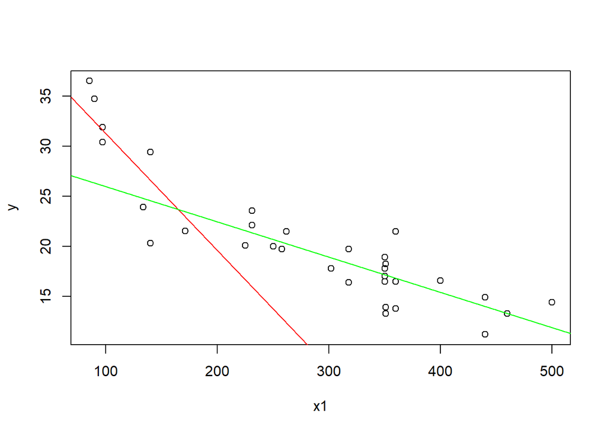

```r
# this allows us to have two lines with possibly different intercepts and slopes
plot(y ~ x1, data=table.b3)
coef <- model1$coefficients
abline(model1, col="red")
abline(a=coef[1]+coef[3],b=coef[2]+coef[4], col="green")
```

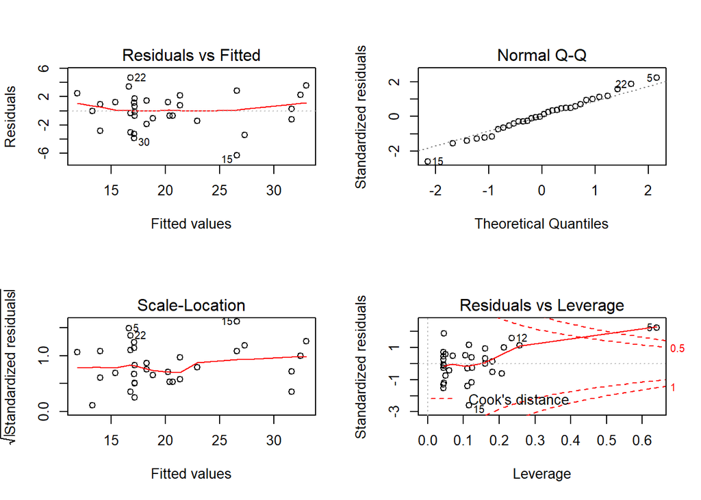

```r
par(mfrow=c(2,2))
plot(model1)
```

As we can see from the top-right plot, the hypothesis of Normality for the residuals seems to be sort of justified, except for a few possible outliers which have been labeled as 22, 5 and 15. On the other side, the bottom-right plot does not necessarily show evidence that 22 and 15 are in fact influential, since their Cook’s distance (which measures how much the removal of a given observation would affect the regression results) does not go beyond the threshold of 0.5, while a critical threshold of 1 has been proposed by the authors of the DAAG book.

**(d) Plot the residuals against the variable x7 (number of transmission speeds), again using x11 as a group variable. Is there anything striking about this plot?**

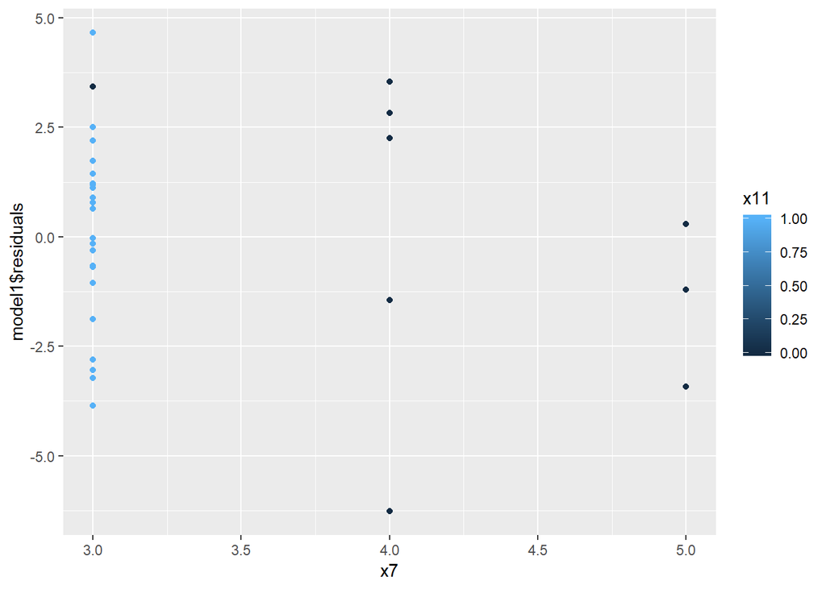

```r
library(ggplot2)
par(mfrow=c(1,1))
ggplot(table.b3, aes(x = x7, y = model1$residuals, colour = x11)) +
  geom_point()
```

What strikes us is that the best fitting observations, that is those having the smallest residuals, seem to concentrate on the level 3 for x7, while the other two levels (4 and 5) contain observations with relatively large residuals. Intuitively, the type of transmission is a relevant predictor of miles/gallon if we are talking about a car having 3 transmission speeds, while the relationship deteriorates for other classes.

# DAAG - Chapter 8

## Exercise 1

**The following table shows numbers of occasions when inhibition (i.e., no flow of current across a membrane) occurred within 120 s, for different concentrations of the protein peptide-C (data are used with the permission of Claudia Haarmann, who obtained these data in the course of her PhD research). The outcome yes implies that inhibition has occurred.** **conc 0.1 0.5 1 10 20 30 50 70 80 100 150** **no 7 1 10 9 2 9 13 1 1 4 3** **yes 0 0 3 4 0 6 7 0 0 1 7**

**Use logistic regression to model the probability of inhibition as a function of protein concentration.**

The *Logistic Regression* is the process of estimating the parameters of a logistic model via maximum likelihood method. The analysis assumes that individuals respond independently with a probability, estimated from the data, that on a logistic scale is a linear function of the predictor variable. In R we use the function ‘glm()’, of ‘*generalized linear models*’, to perform the analysis.

```r
# Variables:
protein_concentration <- c(.1, .5, 1, 10, 20, 30, 50, 70, 80, 100, 150)
no <- c(7, 1, 10, 9, 2, 9, 13, 1, 1, 4, 3)
yes <- c(0, 0, 3, 4, 0, 6, 7, 0, 0, 1 ,7)

# Total number:
total <- no + yes

# Probability of inhibition:
probability_of_inhibition <- yes/total

# Logistic Regression:
inhib.glm <- glm(probability_of_inhibition ~ protein_concentration,
                 family=binomial(link="logit"), weights=total)

summary(inhib.glm)
```

```
##
## Call:
## glm(formula = probability_of_inhibition ~ protein_concentration,
##     family = binomial(link = "logit"), weights = total)
##
## Deviance Residuals:
##     Min       1Q   Median       3Q      Max
## -1.8159  -1.0552  -0.6878   0.3667   1.0315
##
## Coefficients:
##                       Estimate Std. Error z value Pr(>|z|)
## (Intercept)           -1.32701    0.33837  -3.922 8.79e-05 ***
## protein_concentration  0.01215    0.00496   2.450   0.0143 *
## ---
## Signif. codes:  0 '***' 0.001 '**' 0.01 '*' 0.05 '.' 0.1 ' ' 1
##
## (Dispersion parameter for binomial family taken to be 1)
##
##     Null deviance: 16.683  on 10  degrees of freedom
## Residual deviance: 10.389  on  9  degrees of freedom
## AIC: 30.988
##
## Number of Fisher Scoring iterations: 4
```

From the output of the ‘summary()’ function one can notice that both the intercept and the protein concentration are statistically significant.

The logistic regression coefficients give the change in the log odds of the outcome for a one unit increase in the predictor variable. In that case, we have that for every one unit change in protein concentration, the log odds of probability of inhibition (versus non-inhibition/flow of current across a membrane) increases by 0.012.

Below follows a graph showing the probability of inhibition versus protein concentration and the corresponding fitted logistic model.

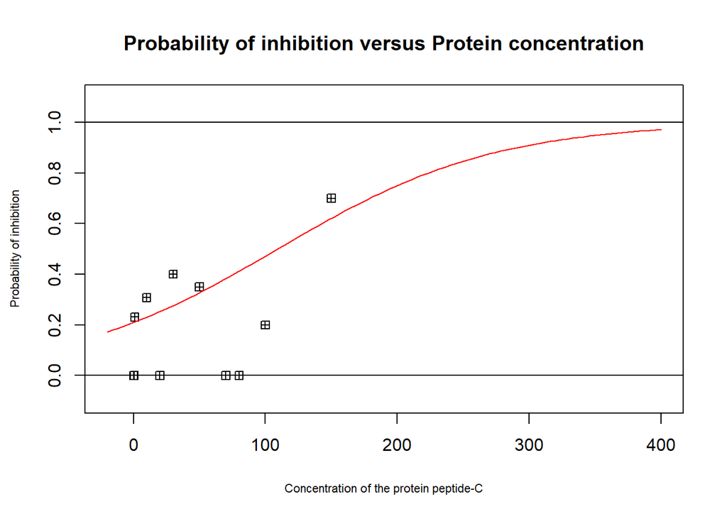

```r
#Plot:
plot(protein_concentration, probability_of_inhibition, pch=12,
    ylim=c(-0.1,1.1),xlim=c(-20.0,400.0),
    ylab="Probability of inhibition", xlab="Concentration of the protein peptide-C",
    cex.lab=.7, main="Probability of inhibition versus Protein concentration")

abline(h = 1)
abline(h = 0)

coef=inhib.glm$coefficients
curve(exp(coef[1]+coef[2]*x)/(1+exp(coef[1]+coef[2]*x)), add=TRUE, col="red")
```

## Exercise 2

**In the data set $\texttt{minor.head.injury}$, obtain a logistic regression model relating $\texttt{clinically.important.brain.injury}$ to other variables. Patients whose risk is sufficiently high will be sent for CT (computed tomography). Using a risk threshold of 0.025 (2.5%), turn the result into a decision rule for use of CT.**

```r
#importing data
library(DAAG)
data <- head.injury
#transforming columns into factors
data[] <- lapply( data, factor)
summary(data)
```

```
##  age.65   amnesia.before basal.skull.fracture GCS.decrease GCS.13
##  0:2759   0:2482         0:2903               0:3050       0:3004
##  1: 362   1: 639         1: 218               1:  71       1: 117
##  GCS.15.2hours high.risk loss.of.consciousness open.skull.fracture
##  0:2726        0:2363    0:2772                0:3006
##  1: 395        1: 758    1: 349                1: 115
##  vomiting clinically.important.brain.injury
##  0:2813   0:2871
##  1: 308   1: 250
```

```r
head(data)
```

```
##   age.65 amnesia.before basal.skull.fracture GCS.decrease GCS.13
## 1      0              1                    0            0      0
## 2      0              0                    0            0      0
## 3      0              0                    0            0      0
## 4      0              0                    0            0      0
## 5      0              0                    0            0      0
## 6      0              1                    0            0      0
##   GCS.15.2hours high.risk loss.of.consciousness open.skull.fracture
## 1             0         0                     0                   0
## 2             0         0                     0                   0
## 3             0         0                     0                   0
## 4             1         0                     0                   0
## 5             1         0                     0                   0
## 6             0         0                     0                   0
##   vomiting clinically.important.brain.injury
## 1        0                                 0
## 2        0                                 0
## 3        0                                 0
## 4        0                                 0
## 5        0                                 0
## 6        0                                 0
```

```r
#fitting a logit model
attach(data)
model <- glm(clinically.important.brain.injury ~ ., data=data, family="binomial")
summary(model)
```

```
##
## Call:
## glm(formula = clinically.important.brain.injury ~ ., family = "binomial",
##     data = data)
##
## Deviance Residuals:
##     Min       1Q   Median       3Q      Max
## -2.2774  -0.3511  -0.2095  -0.1489   3.0028
##
## Coefficients:
##                        Estimate Std. Error z value Pr(>|z|)
## (Intercept)             -4.4972     0.1629 -27.611  < 2e-16 ***
## age.651                  1.3734     0.1827   7.518 5.56e-14 ***
## amnesia.before1          0.6893     0.1725   3.996 6.45e-05 ***
## basal.skull.fracture1    1.9620     0.2064   9.504  < 2e-16 ***
## GCS.decrease1           -0.2688     0.3680  -0.730 0.465152
## GCS.131                  1.0613     0.2820   3.764 0.000168 ***
## GCS.15.2hours1           1.9408     0.1663  11.669  < 2e-16 ***
## high.risk1               1.1115     0.1591   6.984 2.86e-12 ***
## loss.of.consciousness1   0.9554     0.1959   4.877 1.08e-06 ***
## open.skull.fracture1     0.6304     0.3151   2.001 0.045424 *
## vomiting1                1.2334     0.1961   6.290 3.17e-10 ***
## ---
## Signif. codes:  0 '***' 0.001 '**' 0.01 '*' 0.05 '.' 0.1 ' ' 1
##
## (Dispersion parameter for binomial family taken to be 1)
##
##     Null deviance: 1741.6  on 3120  degrees of freedom
## Residual deviance: 1201.3  on 3110  degrees of freedom
## AIC: 1223.3
##
## Number of Fisher Scoring iterations: 6
```

Now we have to make a decision rule, using a risk threshold of 2.5%.

```r
#building the vector of predictions with function predict.glm()
predictions <- predict.glm(model, data, type="response")
#now we build a dataframe whose first column represents the ID of the observation
#and whose second column is the probability predicted by the model
id <- c(1:length(predictions))
results <- data.frame(id=id, prob=predictions)
#risk threshold rule
mask = results$prob > 0.025
ct <- results[mask,]
#ct contains all the observations that require computed tomography according to our model
#and the risk threshold chosen.
ct[1:10,] # 10 first lines
```

```
##    id       prob
## 4   4 0.07199225
## 5   5 0.07199225
## 9   9 0.11791784
## 23 23 0.03274389
## 24 24 0.07199225
## 27 27 0.05454979
## 29 29 0.38402040
## 30 30 0.02814555
## 31 31 0.03274389
## 33 33 0.03119104
```

```r
ct[(nrow(ct)-10):nrow(ct),] # 10 last lines
```

```
##        id       prob
## 3102 3102 0.06318154
## 3103 3103 0.03274389
## 3108 3108 0.03274389
## 3110 3110 0.19407441
## 3111 3111 0.29665633
## 3112 3112 0.14917835
## 3113 3113 0.04213676
## 3115 3115 0.06318154
## 3116 3116 0.03683364
## 3117 3117 0.19077316
## 3118 3118 0.10411396
```

## Exercise 5

**Use the function logisticsim() (in the DAAG package) to simulate data from a logistic regression model to study the glm() function. For example, you might try experiments such as the following:**

**(a) Simulate 100 observations from the model**
$$logit(x) = 2 − 4x$$
**for x = 0, 0.01, 0.02, . . . , 1.0. [This is the default setting for logisticsim().]**

Let’s play around with the logisticsim() function, which simulates data from a logistic model. The first experiment uses the default values for the intercept, slope, and x data.

```r
library(DAAG)

data <- logisticsim()
```

**(b) Plot the responses (y) against the “dose” (x). Note how the pattern of 0s and 1s changes as x increases.**

Let’s plot the results:

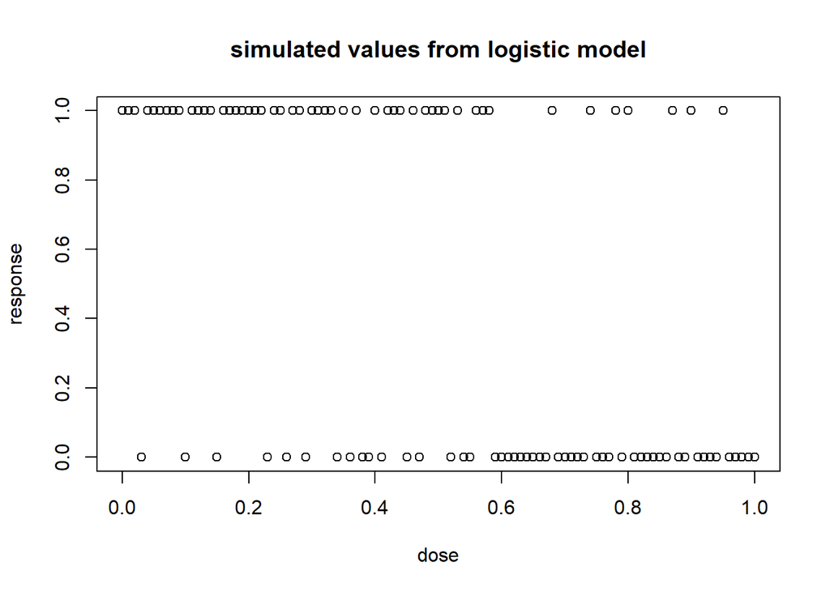

```r
plot(data, main="simulated values from logistic model", xlab="dose", ylab="response")
```

Generally speaking, it looks like y gives a 1 response as x->0, while we witness more 0 responses as x->1, clearly as a result of the choice for the default parameters.

**(c) Fit the logistic regression model to the simulated data, using the binomial family. Compare the estimated coefficients with the true coefficients. Are the estimated coefficients within about 2 standard errors of the truth?**

We now fit a GLM using a binomial distribution (whose variant with logit link function (which is also the canonical one) is in fact what we call “logistic regression”).

```r
model3 <- glm(data$y ~ data$x, family=binomial)
# again, there is no need to explicit the link function

# since we are using the canonical, which is the default in this R routine
summary(model3)
```

```
##
## Call:
## glm(formula = data$y ~ data$x, family = binomial)
##
## Deviance Residuals:
##     Min       1Q   Median       3Q      Max
## -2.0685  -0.8428  -0.4587   0.8467   2.0546
##
## Coefficients:
##             Estimate Std. Error z value Pr(>|z|)
## (Intercept)   2.1444     0.5143   4.169 3.06e-05 ***
## data$x       -4.3430     0.9228  -4.707 2.52e-06 ***
## ---
## Signif. codes:  0 '***' 0.001 '**' 0.01 '*' 0.05 '.' 0.1 ' ' 1
##
## (Dispersion parameter for binomial family taken to be 1)
##
##     Null deviance: 140.01  on 100  degrees of freedom
## Residual deviance: 110.13  on  99  degrees of freedom
## AIC: 114.13
##
## Number of Fisher Scoring iterations: 3
```

Recall the true coefficients were 2 for the intercept and -4 for the slope of ‘x’. To comment on the difference between estimated and true parameters, we can try to see if the fitted ones are within 2 standard deviations from the truth, for example.

```r
coef <- model3$coefficients
stds <- summary(model3)$coefficients[,2] # the parameters' standard deviations
(2 - 2 * stds[1]) <= coef[1] && coef[1] <= (2 + 2 * stds[1])
```

```
## [1] TRUE
```

```r
(-4 - 2 * stds[2]) <= coef[2] && coef[2] <= (-4 + 2 * stds[2])
```

```
## [1] TRUE
```

**(d) Compare the estimated logit function with the true logit function. How well do you think the fitted logistic model would predict future observations? For a concrete indication of the difference, simulate a new set of 100 observations at the same x values, using a specified pseudorandom number generator seed and the true model. Then simulate some predicted observations using the estimated model and the same seed.**

Let’s try to understand how well would the fitted model predict future observations. Here we plot the true and fitted curves, exploiting the analytical form for the logistic model.

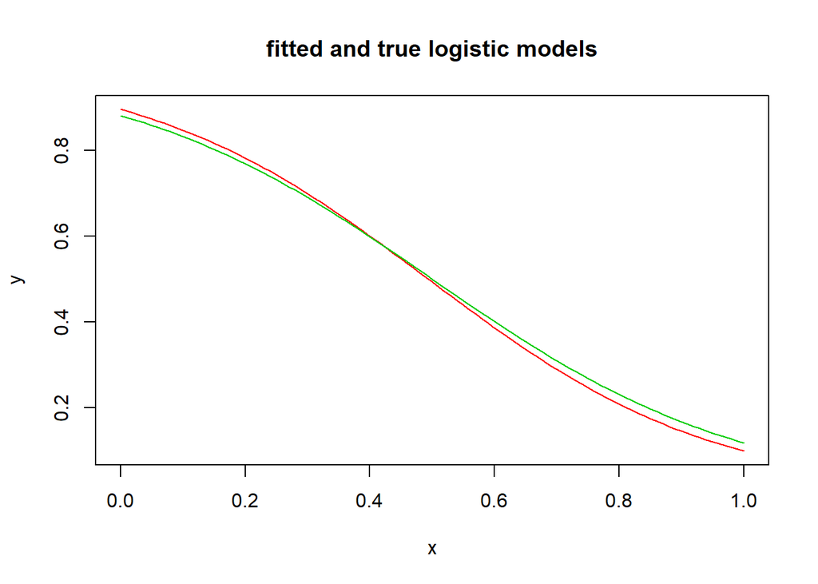

```r
coef <- model3$coefficients
curve(exp(coef[1]+coef[2]*data$x)/(1+exp(coef[1]+coef[2]*data$x)), col=2, main="fitted and true logistic models", xlab="x", ylab="y")
curve(exp(2 - 4*data$x)/(1+exp(2 - 4*data$x)), add=T,col=3)
```

To answer the question, we will simulate 100 values as above using a predefined seed and the true model, and then compare with the predicted result under the fitted model.

```r
seed <- 123 # the seed to be used
data2 <- logisticsim(seed=seed) # generate data
# predict values using the logistic formula
pred <- exp(coef[1]+coef[2]*data2$x)/(1+exp(coef[1]+coef[2]*data2$x))

pred <- ifelse(pred >= 0.5, 1, 0)
# to give an output consistent with the domain of y, we decide to
# put a threshold at 0.5 and classify as 1 the
# predicted values which are above, and 0 those below
```

We can also compute some descriptive statistics of the two vectors to have an idea of their similarity:

```r
mean(data2$y)
```

```
## [1] 0.4950495
```

```r
mean(pred)
```

```
## [1] 0.4950495
```

```r
var(data2$y)
```

```
## [1] 0.2524752
```

```r
var(pred)
```

```
## [1] 0.2524752
```

As we can see, the mean of the two sets of values is very close, and the same holds for the dispersion, suggesting the predictions using the fitted model are very accurate.

## Exercise 6

**As in the previous exercise, the function poissonsim() allows for experimentation with Poisson regression. In particular, poissonsim() can be used to simulate Poisson responses with log-rates equal to a + bx, where a and b are fixed values by default.**

**(a) Simulate 100 Poisson responses using the model**
$$log(\lambda) = 2 − 4x$$
**for x = 0, 0.01, 0.02 . . . , 1.0. Fit a Poisson regression model to these data, and compare the estimated coefficients with the true coefficients. How well does the estimated model predict future observations?**

Let’s simulate 100 values from a Poisson model with default parameters:

```r
data3 <- poissonsim() # generate data
model4 <- glm(data3$y ~ data3$x, family=poisson) # fit the model
model4$coefficients
```

```
## (Intercept)     data3$x
##    2.118262   -4.398362
```

To understand how well the estimated model predicts future observations we can repeat the process used with logistic regression.

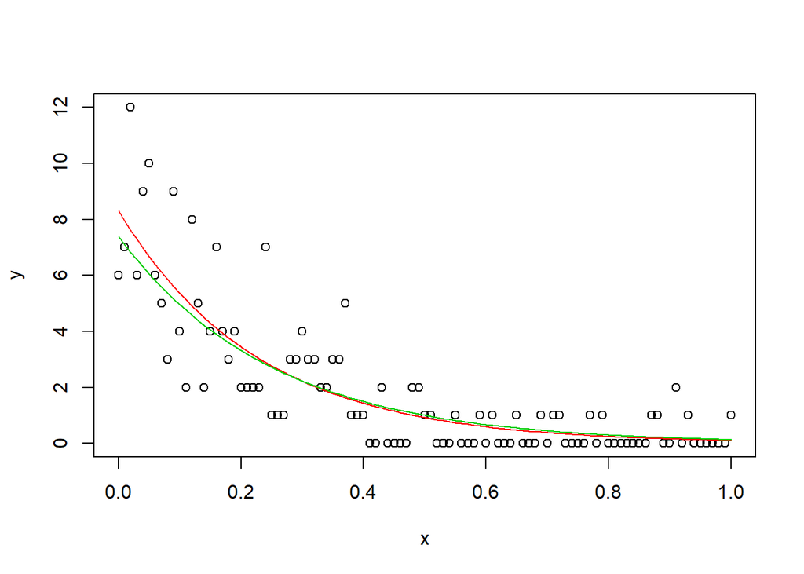

```r
coef <- model4$coefficients
plot(data3)
curve(exp(coef[1]+coef[2]*data3$x), add=T, col=2, main="fitted and true Poisson model")
curve(exp(2 - 4*data3$x), add=T,col=3)
```

To answer the question more precisely, we will simulate 100 values as above using a predefined seed and the true model, and then compare with the predicted result under the fitted model.

```r
seed <- 123
data4 <- poissonsim(seed=seed) # generate data
pred <- exp(coef[1]+coef[2]*data4$x) # predict values using the estimated model
mean(data4$y)
```

```
## [1] 1.950495
```

```r
mean(pred)
```

```
## [1] 1.891089
```

```r
var(data4$y)
```

```
## [1] 6.807525
```

```r
var(pred)
```

```
## [1] 4.600607
```

As we can see, the results are not really close, so we expect the fitted model will not have a really good generalization ability.

**(b) Simulate 100 Poisson responses using the model**
$$log(\lambda) = 2 − bx$$
**where b is normally distributed with mean 4 and standard deviation 5. [Use the argument slope.sd=5 in the poissonsim() function.] How do the results using the poisson and quasipoisson families differ?**

We now simulate 100 values using a Poisson model where the log of the lambda parameter depends linearly on a Normal random variable with mean 4 and std 5. To achieve this, we just need to specify slope.std=5, and b will be set to b + rnornm(n, slope.std) where n is the length of the x vector, as justified by the implementation of ‘poissonsim’ on Github at https://github.com/cran/DAAG/blob/master/R/poissonsim.R.

```r
data5 <- poissonsim(b=4, slope.sd=5)
model5 <- glm(data5$y ~ data5$x, family=poisson)
summary(model5)
```

```
##
## Call:
## glm(formula = data5$y ~ data5$x, family = poisson)
##
## Deviance Residuals:
##     Min       1Q   Median       3Q      Max
## -229.65   -82.42   -40.00   -20.97   728.12
##
## Coefficients:
##             Estimate Std. Error z value Pr(>|z|)
## (Intercept) 5.000444   0.006512   767.9   <2e-16 ***
## data5$x     5.179528   0.007785   665.3   <2e-16 ***
## ---
## Signif. codes:  0 '***' 0.001 '**' 0.01 '*' 0.05 '.' 0.1 ' ' 1
##
## (Dispersion parameter for poisson family taken to be 1)
##
##     Null deviance: 2625552  on 100  degrees of freedom
## Residual deviance: 1910521  on  99  degrees of freedom
## AIC: 1911129
##
## Number of Fisher Scoring iterations: 8
```

Let’s compare now the results using a quasipoisson model:

```r
model6 <- glm(data5$y ~ data5$x, family=quasipoisson)
summary(model6)
```

```
##
## Call:
## glm(formula = data5$y ~ data5$x, family = quasipoisson)
##
## Deviance Residuals:
##     Min       1Q   Median       3Q      Max
## -229.65   -82.42   -40.00   -20.97   728.12
##
## Coefficients:
##             Estimate Std. Error t value Pr(>|t|)
## (Intercept)    5.000      1.447   3.456 0.000808 ***
## data5$x        5.180      1.729   2.995 0.003468 **
## ---
## Signif. codes:  0 '***' 0.001 '**' 0.01 '*' 0.05 '.' 0.1 ' ' 1
##
## (Dispersion parameter for quasipoisson family taken to be 49352.8)
##
##     Null deviance: 2625552  on 100  degrees of freedom
## Residual deviance: 1910521  on  99  degrees of freedom
## AIC: NA
##
## Number of Fisher Scoring iterations: 8
```

Recall that quasipoisson uses quasi-likelihood as an estimation procedure under the hood. As we can see, the estimates for the parameters are left unchanged, since the estimating equations are still the same. On the other side, the standard deviations of the estimates have increased. In fact, with quasipoisson regression we are relaxing the assumption that the dispersion parameter $\phi$ of the Poisson model is equal to 1. Then, it might be the case that the model was suffering from overdispersion, that is a $\phi$ > 1, by which the variance of $Y$ is greater than its theoretical value.